# Part I - FORD GO BIKE DATASET EXPLORATION

## by ODINIGWE CHINYERE ROSEMARY

## Introduction

> Ford GoBike, like other bike share systems, consists of a fleet of specially designed, sturdy and durable bikes that are locked into a network of docking stations throughout the city. The bikes can be unlocked from one station and returned to any other station in the system, making them ideal for one-way trips. The bikes are available for use 24 hours/day, 7 days/week, 365 days/year and riders have access to all bikes in the network when they become a member or purchase a pass. This dataset includes information about individual rides made in a bike-sharing/rental system covering the greater San Francisco Bay area.This dataset basically contains 183412 bike ride records with the features below;

## Variables

- **duration_sec** : Trip duration
- **start_time** : Trip starting time
- **end_time** : Trip end time
- **start_station_id** : Unique ID of trip start station
- **start_station_name** : name of trip start station
- **start_station_latitude** : Latitude of trip start station
- **start_station_longitude** : Longitude of trip start station
- **end_station_id** : Unique ID of trip end station
- **end_station_name** : name of trip end station
- **end_station_latitude** : Latitude of trip end station
- **end_station_longitude** : Longitude of trip end station
- **bike_id** : Unique ID of rented bikes
- **user_type** : Bike user type
  - Subscriber -member (rents bike regulary based on subscription)
  - Customer - a person that rented a bike but might not come back for more rentals)
- **member_birth_year** : Birth year of bike user/member
- **member_gender** : Sex of bike user
- **bike_share_for_all_trip** :Boolean to track members who are enrolled in the "Bike Share for all" program.

## Preliminary Wrangling

```python
# import all packages and set plots to be embedded inline
import numpy as np
import pandas as pd
import matplotlib.pyplot as plt
import seaborn as sb

%matplotlib inline


import warnings
warnings.filterwarnings('ignore')
```

## Gathering Data

```python
#load datasets for flight records in the 19s
bike_2019=pd.read_csv('201902-fordgobike-tripdata.csv')
```

## Assessing Data

```python
#check the first 5 observations of the dataset
bike_2019.head()
```

|  | duration_sec | start_time | end_time | start_station_id | start_station_name | start_station_latitude | start_station_longitude | end_station_id | end_station_name | end_station_latitude | end_station_longitude | bike_id | user_type | member_birth_year | member_gender | bike_share_for_all_trip |
| --- | --- | --- | --- | --- | --- | --- | --- | --- | --- | --- | --- | --- | --- | --- | --- | --- |
| 0 | 52185 | 2019-02-28 17:32:10.1450 | 2019-03-01 08:01:55.9750 | 21.0 | Montgomery St BART Station (Market St at 2nd St) | 37.789625 | -122.400811 | 13.0 | Commercial St at Montgomery St | 37.794231 | -122.402923 | 4902 | Customer | 1984.0 | Male | No |
| 1 | 42521 | 2019-02-28 18:53:21.7890 | 2019-03-01 06:42:03.0560 | 23.0 | The Embarcadero at Steuart St | 37.791464 | -122.391034 | 81.0 | Berry St at 4th St | 37.775880 | -122.393170 | 2535 | Customer | NaN | NaN | No |
| 2 | 61854 | 2019-02-28 12:13:13.2180 | 2019-03-01 05:24:08.1460 | 86.0 | Market St at Dolores St | 37.769305 | -122.426826 | 3.0 | Powell St BART Station (Market St at 4th St) | 37.786375 | -122.404904 | 5905 | Customer | 1972.0 | Male | No |
| 3 | 36490 | 2019-02-28 17:54:26.0100 | 2019-03-01 04:02:36.8420 | 375.0 | Grove St at Masonic Ave | 37.774836 | -122.446546 | 70.0 | Central Ave at Fell St | 37.773311 | -122.444293 | 6638 | Subscriber | 1989.0 | Other | No |
| 4 | 1585 | 2019-02-28 23:54:18.5490 | 2019-03-01 00:20:44.0740 | 7.0 | Frank H Ogawa Plaza | 37.804562 | -122.271738 | 222.0 | 10th Ave at E 15th St | 37.792714 | -122.248780 | 4898 | Subscriber | 1974.0 | Male | Yes |

```python
#check the last 5 observations of the dataset
bike_2019.tail()
```

|  | duration_sec | start_time | end_time | start_station_id | start_station_name | start_station_latitude | start_station_longitude | end_station_id | end_station_name | end_station_latitude | end_station_longitude | bike_id | user_type | member_birth_year | member_gender | bike_share_for_all_trip |
| --- | --- | --- | --- | --- | --- | --- | --- | --- | --- | --- | --- | --- | --- | --- | --- | --- |
| 183407 | 480 | 2019-02-01 00:04:49.7240 | 2019-02-01 00:12:50.0340 | 27.0 | Beale St at Harrison St | 37.788059 | -122.391865 | 324.0 | Union Square (Powell St at Post St) | 37.788300 | -122.408531 | 4832 | Subscriber | 1996.0 | Male | No |
| 183408 | 313 | 2019-02-01 00:05:34.7440 | 2019-02-01 00:10:48.5020 | 21.0 | Montgomery St BART Station (Market St at 2nd St) | 37.789625 | -122.400811 | 66.0 | 3rd St at Townsend St | 37.778742 | -122.392741 | 4960 | Subscriber | 1984.0 | Male | No |
| 183409 | 141 | 2019-02-01 00:06:05.5490 | 2019-02-01 00:08:27.2200 | 278.0 | The Alameda at Bush St | 37.331932 | -121.904888 | 277.0 | Morrison Ave at Julian St | 37.333658 | -121.908586 | 3824 | Subscriber | 1990.0 | Male | Yes |
| 183410 | 139 | 2019-02-01 00:05:34.3600 | 2019-02-01 00:07:54.2870 | 220.0 | San Pablo Ave at MLK Jr Way | 37.811351 | -122.273422 | 216.0 | San Pablo Ave at 27th St | 37.817827 | -122.275698 | 5095 | Subscriber | 1988.0 | Male | No |
| 183411 | 271 | 2019-02-01 00:00:20.6360 | 2019-02-01 00:04:52.0580 | 24.0 | Spear St at Folsom St | 37.789677 | -122.390428 | 37.0 | 2nd St at Folsom St | 37.785000 | -122.395936 | 1057 | Subscriber | 1989.0 | Male | No |

```python
#check random 5 observations of the dataset
bike_2019.sample()
```

|  | duration_sec | start_time | end_time | start_station_id | start_station_name | start_station_latitude | start_station_longitude | end_station_id | end_station_name | end_station_latitude | end_station_longitude | bike_id | user_type | member_birth_year | member_gender | bike_share_for_all_trip |
| --- | --- | --- | --- | --- | --- | --- | --- | --- | --- | --- | --- | --- | --- | --- | --- | --- |
| 43607 | 809 | 2019-02-22 16:15:10.8090 | 2019-02-22 16:28:40.1590 | 104.0 | 4th St at 16th St | 37.767045 | -122.390833 | 133.0 | Valencia St at 22nd St | 37.755213 | -122.420975 | 4617 | Subscriber | 1980.0 | Other | No |

```python
#get info of the various features(variables)
bike_2019.info()
```

```
<class 'pandas.core.frame.DataFrame'>
RangeIndex: 183412 entries, 0 to 183411
Data columns (total 16 columns):
duration_sec               183412 non-null int64
start_time                 183412 non-null object
end_time                   183412 non-null object
start_station_id           183215 non-null float64
start_station_name         183215 non-null object
start_station_latitude     183412 non-null float64
start_station_longitude    183412 non-null float64
end_station_id             183215 non-null float64
end_station_name           183215 non-null object
end_station_latitude       183412 non-null float64
end_station_longitude      183412 non-null float64
bike_id                    183412 non-null int64
user_type                  183412 non-null object
member_birth_year          175147 non-null float64
member_gender              175147 non-null object
bike_share_for_all_trip    183412 non-null object
dtypes: float64(7), int64(2), object(7)
memory usage: 22.4+ MB
```

- The start and end time datatype needs to be changed to datetime format
- The start,end station id and bike id needs to be changed to strings
- The user type and member gender needs to be changed to categorical datatype
- The member birth year datatype needs to be changed to integers

```python
#get shape of dataset
bike_2019.shape
```

```
(183412, 16)
```

```python
# Check for missing values
#get info of the various features(variables)
bike_2019.isnull().sum()
```

```
duration_sec                  0
start_time                    0
end_time                      0
start_station_id            197
start_station_name          197
start_station_latitude        0
start_station_longitude       0
end_station_id              197
end_station_name            197
end_station_latitude          0
end_station_longitude         0
bike_id                       0
user_type                     0
member_birth_year          8265
member_gender              8265
bike_share_for_all_trip       0
dtype: int64
```

We have null values present in start station id & name, end station id & name, member birth year and gender

```python
# lets get the descriptive analysis of the numerical data

bike_2019.describe()
```

|  | duration_sec | start_station_id | start_station_latitude | start_station_longitude | end_station_id | end_station_latitude | end_station_longitude | bike_id | member_birth_year |
| --- | --- | --- | --- | --- | --- | --- | --- | --- | --- |
| count | 183412.000000 | 183215.000000 | 183412.000000 | 183412.000000 | 183215.000000 | 183412.000000 | 183412.000000 | 183412.000000 | 175147.000000 |
| mean | 726.078435 | 138.590427 | 37.771223 | -122.352664 | 136.249123 | 37.771427 | -122.352250 | 4472.906375 | 1984.806437 |
| std | 1794.389780 | 111.778864 | 0.099581 | 0.117097 | 111.515131 | 0.099490 | 0.116673 | 1664.383394 | 10.116689 |
| min | 61.000000 | 3.000000 | 37.317298 | -122.453704 | 3.000000 | 37.317298 | -122.453704 | 11.000000 | 1878.000000 |
| 25% | 325.000000 | 47.000000 | 37.770083 | -122.412408 | 44.000000 | 37.770407 | -122.411726 | 3777.000000 | 1980.000000 |
| 50% | 514.000000 | 104.000000 | 37.780760 | -122.398285 | 100.000000 | 37.781010 | -122.398279 | 4958.000000 | 1987.000000 |
| 75% | 796.000000 | 239.000000 | 37.797280 | -122.286533 | 235.000000 | 37.797320 | -122.288045 | 5502.000000 | 1992.000000 |
| max | 85444.000000 | 398.000000 | 37.880222 | -121.874119 | 398.000000 | 37.880222 | -121.874119 | 6645.000000 | 2001.000000 |

```python
# lets check for duplicates

bike_2019.duplicated().sum()
```

```
0
```

```python
#lets get the value counts for the members birth year
bike_2019['member_birth_year' ].value_counts()
```

```
1988.0    10236
1993.0     9325
1989.0     8972
1990.0     8658
1991.0     8498
1992.0     8250
1987.0     8018
1986.0     7973
1994.0     7660
1995.0     7423
1985.0     7028
1984.0     6562
1983.0     5954
1980.0     5024
1982.0     4990
1996.0     4640
1981.0     4345
1979.0     3756
1997.0     3481
1998.0     3208
1978.0     2830
1977.0     2725
1974.0     2633
1999.0     2528
1975.0     2503
1976.0     2442
1973.0     2080
1968.0     1928
1971.0     1924
1972.0     1909
          ...
1954.0      301
1952.0      189
1951.0      180
1950.0      178
1953.0      158
1947.0      135
1955.0      134
1945.0      105
1949.0       99
1931.0       89
1900.0       53
1948.0       51
2001.0       34
1943.0       30
1942.0       21
1933.0       20
1946.0       19
1902.0       11
1939.0       11
1941.0        9
1901.0        6
1938.0        3
1920.0        3
1934.0        2
1944.0        2
1930.0        1
1910.0        1
1927.0        1
1928.0        1
1878.0        1
Name: member_birth_year, Length: 75, dtype: int64
```

From the information above,the **1988** has the highest number of members.

```python
#lets get the value counts for the members gender
bike_2019['member_gender' ].value_counts()
```

```
Male      130651
Female     40844
Other       3652
Name: member_gender, dtype: int64
```

```python
#lets get the value counts for the user type
bike_2019['user_type' ].value_counts()
```

```
Subscriber    163544
Customer       19868
Name: user_type, dtype: int64
```

```python
#lets get the unique start station names
bike_2019['start_station_name' ].unique()
```

```
array(['Montgomery St BART Station (Market St at 2nd St)',
       'The Embarcadero at Steuart St', 'Market St at Dolores St',
       'Grove St at Masonic Ave', 'Frank H Ogawa Plaza',
       '4th St at Mission Bay Blvd S', 'Palm St at Willow St',
       'Washington St at Kearny St', 'Post St at Kearny St',
       'Jones St at Post St',
       'Civic Center/UN Plaza BART Station (Market St at McAllister St)',
       'Valencia St at 21st St', 'Channing Way at Shattuck Ave',
       'Bancroft Way at College Ave', 'Howard St at Mary St',
       '22nd St at Dolores St', 'Laguna St at Hayes St',
       '5th St at Folsom', 'Telegraph Ave at 23rd St',
       'Page St at Scott St', 'Lake Merritt BART Station',
       'West St at 40th St', 'The Embarcadero at Sansome St',
       'Folsom St at 9th St', 'University Ave at Oxford St',
       'MLK Jr Way at University Ave', 'The Embarcadero at Bryant St',
       '17th St at Valencia St', 'Valencia St at 16th St',
       'Valencia St at 22nd St', 'Franklin Square',
       'San Pablo Ave at MLK Jr Way', '19th St at Mission St',
       'Market St at 10th St', 'Folsom St at 13th St',
       'San Francisco Ferry Building (Harry Bridges Plaza)',
       '4th St at 16th St', 'Beale St at Harrison St',
       'Broadway at Battery St', 'Cesar Chavez St at Dolores St',
       'San Fernando St at 4th St', 'Grove St at Divisadero',
       'Sanchez St at 17th St', 'Harmon St at Adeline St',
       'Mission Playground', 'Davis St at Jackson St',
       'Haste St at Telegraph Ave', 'Howard St at 8th St',
       'Folsom St at 3rd St', 'Father Alfred E Boeddeker Park',
       'Commercial St at Montgomery St', 'Hubbell St at 16th St',
       'San Francisco Public Library (Grove St at Hyde St)',
       'Bancroft Way at Telegraph Ave', '19th Street BART Station',
       '18th St at Noe St', 'Hyde St at Post St', '24th St at Market St',
       'Vine St at Shattuck Ave',
       'San Francisco Caltrain (Townsend St at 4th St)',
       'Valencia St at Clinton Park',
       'Union Square (Powell St at Post St)', 'Broderick St at Oak St',
       'San Francisco Caltrain Station 2  (Townsend St at 4th St)',
       'North Berkeley BART Station', 'Downtown Berkeley BART',
       'Fell St at Stanyan St', 'San Salvador St at 9th St',
       'Marston Campbell Park', 'Oregon St at Adeline St',
       '11th St at Natoma St', 'Harrison St at 20th St',
```

[output cut: 116 more lines]

```
       'Williams Ave at Apollo St', 'MacArthur Blvd at Telegraph Ave',
       'Bestor Art Park', 'College Ave at Bryant Ave',
       'Miles Ave at Cavour St', 'Saint James Park',
       '14th St at Filbert St', 'Foothill Blvd at Fruitvale Ave',
       'Market St at 8th St', 'Backesto Park (Jackson St at 13th St)',
       '10th Ave at E 15th St', 'Alcatraz Ave at Shattuck Ave',
       '55th St at Telegraph Ave', 'Genoa St at 55th St',
       'Dover St at 57th St', 'San Pablo Park',
       '6th Ave at E 12th St (Temporary Location)', 'Taylor St at 9th St',
       '27th St at MLK Jr Way', 'Foothill Blvd at Harrington Ave',
       '23rd Ave at Foothill Blvd', 'San Pedro St at Hedding St',
       '45th St at MLK Jr Way', '5th St at Taylor St',
       'Foothill Blvd at 42nd Ave', 'Willow St at Vine St',
       '26th Ave at International Blvd', 'Farnam St at Fruitvale Ave',
       '21st Ave at International Blvd', '2nd St at Folsom St'], dtype=object)
```

```python
#lets get the unique end station names
bike_2019['end_station_name' ].unique()
```

```
array(['Commercial St at Montgomery St', 'Berry St at 4th St',
       'Powell St BART Station (Market St at 4th St)',
       'Central Ave at Fell St', '10th Ave at E 15th St',
       'Broadway at Kearny', 'San Jose Diridon Station',
       'Valencia St at 21st St', 'Mission Playground',
       'San Francisco Public Library (Grove St at Hyde St)',
       'Bryant St at 2nd St', 'Shattuck Ave at Hearst Ave',
       'Channing Way at Shattuck Ave', '8th St at Ringold St',
       'Broderick St at Oak St', 'Potrero Ave and Mariposa St',
       'Market St at Franklin St', 'Telegraph Ave at 23rd St',
       '17th St at Dolores St',
       '6th Ave at E 12th St (Temporary Location)',
       'McAllister St at Baker St', 'Telegraph Ave at Carleton St',
       'Genoa St at 55th St', 'Grand Ave at Perkins St',
       'San Francisco Ferry Building (Harry Bridges Plaza)',
       'Folsom St at 9th St', 'Channing Way at San Pablo Ave',
       '2nd St at Townsend St', 'Pierce St at Haight St',
       'Potrero del Sol Park (25th St at Utah St)',
       'Valencia St at 22nd St', 'Jackson Playground',
       'Dolores St at 15th St', '29th St at Church St',
       '19th St at Mission St', 'Bay Pl at Vernon St',
       'Post St at Kearny St',
       'Yerba Buena Center for the Arts (Howard St at 3rd St)',
       '4th St at Mission Bay Blvd S', 'Father Alfred E Boeddeker Park',
       'Market St at 10th St', '24th St at Chattanooga St',
       'Pierce Ave at Market St', 'Fell St at Stanyan St',
       '17th St at Valencia St', 'San Pablo Ave at 27th St',
       'Howard St at Mary St', 'Davis St at Jackson St',
       'Victoria Manalo Draves Park', 'Jersey St at Church St',
       'Haste St at Telegraph Ave', 'Eureka Valley Recreation Center',
       'Washington St at Kearny St', 'Grove St at Divisadero',
       'Parker St at Fulton St', 'El Embarcadero at Grand Ave',
       'Lake Merritt BART Station', 'Hyde St at Post St',
       '24th St at Market St', '5th St at Brannan St',
       '24th St at Bartlett St', 'Townsend St at 5th St',
       'Addison St at Fourth St', 'Broadway at Battery St',
       'Market St at Dolores St', '5th St at Virginia St',
       'Marston Campbell Park', 'University Ave at Oxford St',
       'Valencia St at 24th St', 'Valencia St at Cesar Chavez St',
       'Ryland Park', 'Precita Park', 'Derby St at College Ave',
```

[output cut: 117 more lines]

```
       'Webster St at 19th St', 'San Pablo Park',
       'College Ave at Taft Ave', 'Market St at 8th St', 'Snow Park',
       'San Antonio Park', 'San Jose City Hall',
       'Delmas Ave and San Fernando St', 'Mendell St at Fairfax Ave',
       'Santa Clara St at Almaden Blvd', 'College Ave at Bryant Ave',
       'Foothill Blvd at Fruitvale Ave', 'Palm St at Willow St',
       'Saint James Park', 'Williams Ave at 3rd St',
       'Market St at Park St', 'Almaden Blvd at Balbach St',
       'Almaden Blvd at San Fernando St', 'Foothill Blvd at 42nd Ave',
       'Fruitvale BART Station', 'MacArthur Blvd at Telegraph Ave',
       'Williams Ave at Apollo St', 'Mission St at 1st St',
       'San Pedro St at Hedding St', 'Oak St at 1st St',
       'Farnam St at Fruitvale Ave', '26th Ave at International Blvd',
       '16th St Depot', '21st Ave at International Blvd',
       'Willow St at Vine St', '2nd St at Folsom St'], dtype=object)
```

## Cleaning Data

```python
#Make a copy of the dataframe
bike_19=bike_2019.copy()
```

### Issue 1- Dropping missing values

```python
bike_19.dropna(inplace = True)
```

```python
bike_19.isnull().sum()
```

```
duration_sec               0
start_time                 0
end_time                   0
start_station_id           0
start_station_name         0
start_station_latitude     0
start_station_longitude    0
end_station_id             0
end_station_name           0
end_station_latitude       0
end_station_longitude      0
bike_id                    0
user_type                  0
member_birth_year          0
member_gender              0
bike_share_for_all_trip    0
dtype: int64
```

### Issue 2- Changing all incorrect datatype to appropriate datatypes

```python
bike_19['start_time'] = pd.to_datetime(bike_19['start_time'])
bike_19['end_time'] = pd.to_datetime(bike_19['end_time'])

bike_19[['start_station_id','end_station_id','bike_id']] = bike_19[['start_station_id','end_station_id','bike_id']].astype('str')


bike_19[['user_type','member_gender','bike_share_for_all_trip']] = bike_19[['user_type','member_gender','bike_share_for_all_trip']] .astype('category')

bike_19['member_birth_year'] = bike_19['member_birth_year'].astype('int')
```

```python
bike_19.info()
```

```
<class 'pandas.core.frame.DataFrame'>
Int64Index: 174952 entries, 0 to 183411
Data columns (total 16 columns):
duration_sec               174952 non-null int64
start_time                 174952 non-null datetime64[ns]
end_time                   174952 non-null datetime64[ns]
start_station_id           174952 non-null object
start_station_name         174952 non-null object
start_station_latitude     174952 non-null float64
start_station_longitude    174952 non-null float64
end_station_id             174952 non-null object
end_station_name           174952 non-null object
end_station_latitude       174952 non-null float64
end_station_longitude      174952 non-null float64
bike_id                    174952 non-null object
user_type                  174952 non-null category
member_birth_year          174952 non-null int64
member_gender              174952 non-null category
bike_share_for_all_trip    174952 non-null category
dtypes: category(3), datetime64[ns](2), float64(4), int64(2), object(5)
memory usage: 19.2+ MB
```

### Issue 3- Derive new columns for better analysis

- Duration in minute
- start and end days of the week
- start and end hr
- age of riders

```python
# Add new columns for trip duration in minute

bike_19['duration_min'] = bike_19['duration_sec']/60
```

```python
# Add new columns for days of the week
bike_19['dayoftheweek'] = bike_19['start_time'].dt.strftime('%a')


weekday = ['Mon', 'Tue', 'Wed', 'Thu', 'Fri', 'Sat', 'Sun']
weekday_cat = pd.api.types.CategoricalDtype(ordered=True, categories=weekday)
bike_19['dayoftheweek'] = bike_19['dayoftheweek'].astype(weekday_cat)
```

```python
# Add new columns for start and end hr of the day
bike_19['hr_day'] = bike_19['start_time'].dt.hour
```

```python
# Add new columns for members age from birth year
bike_19['member_age'] = 2019 - bike_19['member_birth_year']
```

```python
bike_19.head(10)
```

|  | duration_sec | start_time | end_time | start_station_id | start_station_name | start_station_latitude | start_station_longitude | end_station_id | end_station_name | end_station_latitude | end_station_longitude | bike_id | user_type | member_birth_year | member_gender | bike_share_for_all_trip | duration_min | dayoftheweek | hr_day | member_age |
| --- | --- | --- | --- | --- | --- | --- | --- | --- | --- | --- | --- | --- | --- | --- | --- | --- | --- | --- | --- | --- |
| 0 | 52185 | 2019-02-28 17:32:10.145 | 2019-03-01 08:01:55.975 | 21.0 | Montgomery St BART Station (Market St at 2nd St) | 37.789625 | -122.400811 | 13.0 | Commercial St at Montgomery St | 37.794231 | -122.402923 | 4902 | Customer | 1984 | Male | No | 869.750000 | Thu | 17 | 35 |
| 2 | 61854 | 2019-02-28 12:13:13.218 | 2019-03-01 05:24:08.146 | 86.0 | Market St at Dolores St | 37.769305 | -122.426826 | 3.0 | Powell St BART Station (Market St at 4th St) | 37.786375 | -122.404904 | 5905 | Customer | 1972 | Male | No | 1030.900000 | Thu | 12 | 47 |
| 3 | 36490 | 2019-02-28 17:54:26.010 | 2019-03-01 04:02:36.842 | 375.0 | Grove St at Masonic Ave | 37.774836 | -122.446546 | 70.0 | Central Ave at Fell St | 37.773311 | -122.444293 | 6638 | Subscriber | 1989 | Other | No | 608.166667 | Thu | 17 | 30 |
| 4 | 1585 | 2019-02-28 23:54:18.549 | 2019-03-01 00:20:44.074 | 7.0 | Frank H Ogawa Plaza | 37.804562 | -122.271738 | 222.0 | 10th Ave at E 15th St | 37.792714 | -122.248780 | 4898 | Subscriber | 1974 | Male | Yes | 26.416667 | Thu | 23 | 45 |
| 5 | 1793 | 2019-02-28 23:49:58.632 | 2019-03-01 00:19:51.760 | 93.0 | 4th St at Mission Bay Blvd S | 37.770407 | -122.391198 | 323.0 | Broadway at Kearny | 37.798014 | -122.405950 | 5200 | Subscriber | 1959 | Male | No | 29.883333 | Thu | 23 | 60 |
| 6 | 1147 | 2019-02-28 23:55:35.104 | 2019-03-01 00:14:42.588 | 300.0 | Palm St at Willow St | 37.317298 | -121.884995 | 312.0 | San Jose Diridon Station | 37.329732 | -121.901782 | 3803 | Subscriber | 1983 | Female | No | 19.116667 | Thu | 23 | 36 |
| 7 | 1615 | 2019-02-28 23:41:06.766 | 2019-03-01 00:08:02.756 | 10.0 | Washington St at Kearny St | 37.795393 | -122.404770 | 127.0 | Valencia St at 21st St | 37.756708 | -122.421025 | 6329 | Subscriber | 1989 | Male | No | 26.916667 | Thu | 23 | 30 |
| 8 | 1570 | 2019-02-28 23:41:48.790 | 2019-03-01 00:07:59.715 | 10.0 | Washington St at Kearny St | 37.795393 | -122.404770 | 127.0 | Valencia St at 21st St | 37.756708 | -122.421025 | 6548 | Subscriber | 1988 | Other | No | 26.166667 | Thu | 23 | 31 |
| 9 | 1049 | 2019-02-28 23:49:47.699 | 2019-03-01 00:07:17.025 | 19.0 | Post St at Kearny St | 37.788975 | -122.403452 | 121.0 | Mission Playground | 37.759210 | -122.421339 | 6488 | Subscriber | 1992 | Male | No | 17.483333 | Thu | 23 | 27 |
| 10 | 458 | 2019-02-28 23:57:57.211 | 2019-03-01 00:05:35.435 | 370.0 | Jones St at Post St | 37.787327 | -122.413278 | 43.0 | San Francisco Public Library (Grove St at Hyde... | 37.778768 | -122.415929 | 5318 | Subscriber | 1996 | Female | Yes | 7.633333 | Thu | 23 | 23 |

```python
#Drop columns not necessary for analysis
bike_19= bike_19.drop(columns = ['start_time','end_time','start_station_id','end_station_id','start_station_latitude','end_station_latitude','start_station_longitude','end_station_longitude','bike_id','member_birth_year','duration_sec'])
```

```python
bike_19.sample(10)
```

|  | start_station_name | end_station_name | user_type | member_gender | bike_share_for_all_trip | duration_min | dayoftheweek | hr_day | member_age |
| --- | --- | --- | --- | --- | --- | --- | --- | --- | --- |
| 18986 | Fulton St at Bancroft Way | MLK Jr Way at University Ave | Subscriber | Male | No | 3.766667 | Tue | 17 | 19 |
| 102234 | Spear St at Folsom St | Post St at Kearny St | Subscriber | Male | No | 10.583333 | Thu | 16 | 60 |
| 82854 | 18th St at Noe St | Mississippi St at 17th St | Subscriber | Male | No | 12.166667 | Mon | 8 | 32 |
| 40234 | Union Square (Powell St at Post St) | 5th St at Brannan St | Customer | Male | No | 5.400000 | Fri | 21 | 22 |
| 163699 | North Berkeley BART Station | Fifth St at Delaware St | Subscriber | Female | No | 6.000000 | Tue | 9 | 33 |
| 24408 | Beale St at Harrison St | 3rd St at Townsend St | Subscriber | Male | No | 7.983333 | Mon | 18 | 31 |
| 20055 | Bancroft Way at College Ave | Bancroft Way at Telegraph Ave | Subscriber | Male | No | 1.583333 | Tue | 14 | 24 |
| 29253 | Folsom St at 19th St | Montgomery St BART Station (Market St at 2nd St) | Subscriber | Female | No | 14.266667 | Mon | 7 | 26 |
| 144432 | San Francisco Ferry Building (Harry Bridges Pl... | 3rd St at Townsend St | Subscriber | Male | No | 10.200000 | Thu | 12 | 39 |
| 18330 | Post St at Kearny St | San Francisco Caltrain Station 2 (Townsend St... | Subscriber | Male | No | 9.500000 | Tue | 18 | 31 |

```python
bike_19.info()
```

```
<class 'pandas.core.frame.DataFrame'>
Int64Index: 174952 entries, 0 to 183411
Data columns (total 9 columns):
start_station_name         174952 non-null object
end_station_name           174952 non-null object
user_type                  174952 non-null category
member_gender              174952 non-null category
bike_share_for_all_trip    174952 non-null category
duration_min               174952 non-null float64
dayoftheweek               174952 non-null category
hr_day                     174952 non-null int64
member_age                 174952 non-null int64
dtypes: category(4), float64(1), int64(2), object(2)
memory usage: 8.7+ MB
```

### What is the structure of your dataset?

> The original dataset is made up of 183412 rows and 16 columns with discription above

> After wrangling,the resulting dataset is made up of 174952 rows and 9 columns with the following new columns generated for analysis purpose
> - duration_minute- extracted from duration_sec
> - member-age- extracted from the birth year
> - dayofthe week & hr_day - extracted from start and end time.

### What is/are the main feature(s) of interest in your dataset?

> The main features of interest are
> - The users demographics with respect to gender, age and user type
> - The number of trips and ride duration as it differs with age ,gender ,time and day of the week.

### What features in the dataset do you think will help support your investigation into your feature(s) of interest?

> The following features will help support my investigation of interest
> - members age and gender
> - hr of the day
> - day of the week
> - trip duration
> - user_type

## Univariate Exploration

### Question- What is the Bike Rental system usage for Feb 2019

- Based on trip duration
- Based on weekdays
- Based on hours of the day

### Visualization-The Distribution of trip duration

```python
bike_19['duration_min'].describe()
```

```
count    174952.000000
mean         11.733379
std          27.370082
min           1.016667
25%           5.383333
50%           8.500000
75%          13.150000
max        1409.133333
Name: duration_min, dtype: float64
```

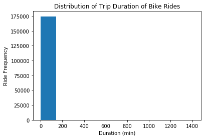

```python
# A simple histogram plot of the variable
plt.hist(data=bike_19, x='duration_min');
plt.title('Distribution of Trip Duration of Bike Rides')
plt.xlabel('Duration (min)')
plt.ylabel('Ride Frequency');
```

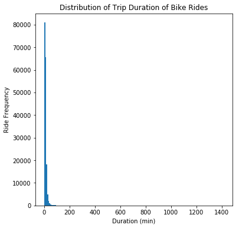

```python
# plotting with a standard-scaled plot
binsize = 8
bins = np.arange(0,bike_19['duration_min'].max()+binsize, binsize)

plt.figure(figsize=[6, 6])
plt.hist(data = bike_19, x = 'duration_min', bins=bins)
plt.title('Distribution of Trip Duration of Bike Rides')
plt.xlabel('Duration (min)')
plt.ylabel('Ride Frequency');
```

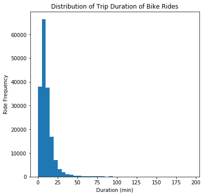

```python
# Investigating further on an even smaller bin size, zooming into the peak region(xlim-200)
bins = np.arange(0,200, 5)

plt.figure(figsize=[6, 6])

plt.hist(data = bike_19, x = 'duration_min', bins=bins)
plt.title('Distribution of Trip Duration of Bike Rides')
plt.xlabel('Duration (min)')
plt.ylabel('Ride Frequency');
```

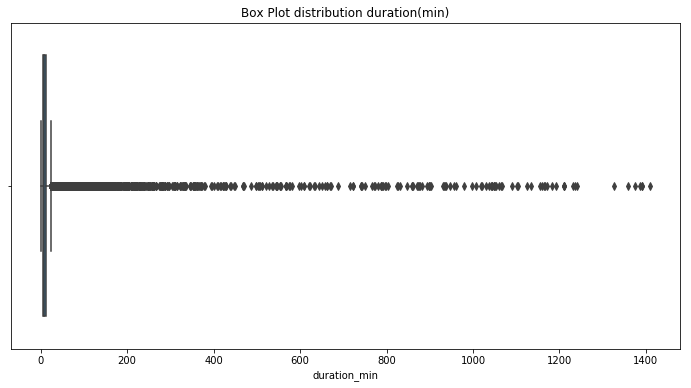

```python
#lets check for outliers with a boxplot

plt.figure(figsize = (12,6))

sb.boxplot(data=bike_19,x='duration_min')
plt.title('Box Plot distribution duration(min)');
```

```python
# Using IQR method to detect outliers
Q1 = bike_19['duration_min'].quantile(0.25)
Q3 = bike_19['duration_min'].quantile(0.75)
IQR = Q3 - Q1
LowerLimit = Q1 - 1.5*IQR  #Data which falls below this is an outlier
UpperLimit = Q3 + 1.5*IQR  #Data which falls above this is an outlier
print(LowerLimit, UpperLimit)
```

```
-6.266666666666667 24.8
```

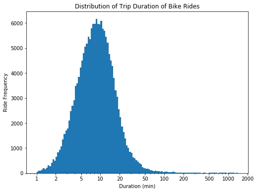

```python
# from plot with smaller bin size, there's a long tail in the distribution, so let's put it on a log scale instead
log_binsize = 0.025
bins = 10 ** np.arange(0, np.log10(bike_19['duration_min'].max())+log_binsize, log_binsize)

plt.figure(figsize=[8, 6])
plt.hist(data = bike_19, x = 'duration_min', bins = bins)
plt.xscale('log')
plt.xticks([1, 2, 5, 10, 20, 50, 100, 200, 500, 1000, 2000], [1, 2, 5, 10, 20, 50, 100, 200, 500, 1000, 2000])
plt.title('Distribution of Trip Duration of Bike Rides')
plt.xlabel('Duration (min)')
plt.ylabel('Ride Frequency');
```

The distribution is still positively skewed due to the presence of the outliers as indicated by the IQR. lets plot another histogram using 100minutes as the Xlim to focus on the most common trips

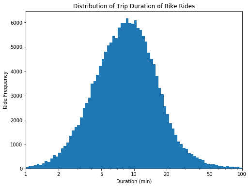

```python
log_binsize = 0.025
bins = 10 ** np.arange(0, np.log10(bike_19['duration_min'].max())+log_binsize, log_binsize)

plt.figure(figsize=[8, 6])
plt.hist(data = bike_19, x = 'duration_min', bins = bins)
plt.xscale('log')
plt.xticks([1, 2, 5, 10, 20, 50, 100, 200, 500, 1000, 2000], [1, 2, 5, 10, 20, 50, 100, 200, 500, 1000, 2000]);
plt.xlim([0,100])
plt.title('Distribution of Trip Duration of Bike Rides')
plt.xlabel('Duration (min)')
plt.ylabel('Ride Frequency');
```

### Observation

> From the plot above, it is observed that
> - The distribution is more clear and its not skewed to the right rather exhibits approximately a normal distribution.
> - Most trips duration was between 5-25mins with the average peak duration being approximately 9mins.
> - There is presence of outliers as shown in IQR calculation

### Visualization- The weekday and hr distribution

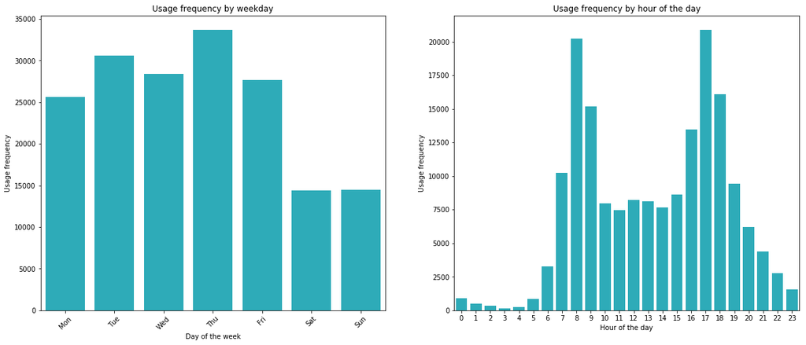

```python
# let's plot the bike usage frequency based on weekday and hours of the day
plt.figure(figsize=[20,8])
plotcolor = sb.color_palette()[9]

plt.subplot(1,2,1)

sb.countplot(data = bike_19, x = 'dayoftheweek', color = plotcolor)
plt.xticks(rotation = 45)
plt.title('Usage frequency by weekday')
plt.xlabel('Day of the week')
plt.ylabel('Usage frequency');

plt.subplot(1,2,2)

sb.countplot(data = bike_19, x = 'hr_day', color = plotcolor)
plt.title('Usage frequency by hour of the day')
plt.xlabel('Hour of the day')
plt.ylabel('Usage frequency');
```

### Observation

> From the plot above, it is observed that
> - The usage frequency peaks during the week is on **Thursday** and **Tuesday**.
> - The peak hours are between **(8-9)hrs** for the morning hours of the day and **(17-18)hrs** for the evening hrs of the day.This can be attributed to the work timeline in san francisco.

### Question- What is the demographics of the FordGo customers for Feb 2019

- The age distribution
- The gender distribution
- The user type distribution
- Are they members of the **Bike share for all Program**

### Visualization- The age distribution

```python
bike_19['member_age'].describe()
```

```
count    174952.000000
mean         34.196865
std          10.118731
min          18.000000
25%          27.000000
50%          32.000000
75%          39.000000
max         141.000000
Name: member_age, dtype: float64
```

Max age from above shows **141**, this indicates presence of outliers.

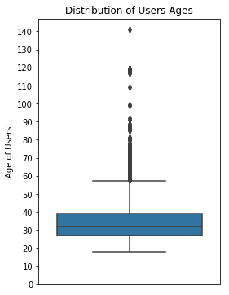

```python
#lets plot a boxplot to show the distribution of ages
plt.figure(figsize = (4,6))

ytick = np.arange(0,bike_19['member_age'].max(),10)
sb.boxplot(data=bike_19,y='member_age')
plt.yticks(ytick,ytick)
plt.title('Distribution of Users Ages')
plt.ylabel('Age of Users');
```

> The data is not distributed evenly and there are outliers. Let's calculate of IQR:

```python
# Using IQR method to detect outliers
Q1 = bike_19['member_age'].quantile(0.25)
Q3 = bike_19['member_age'].quantile(0.75)
IQR = Q3 - Q1
LowerLimit = Q1 - 1.5*IQR  #Data which falls below this is an outlier
UpperLimit = Q3 + 1.5*IQR  #Data which falls above this is an outlier
print(LowerLimit, UpperLimit)
```

```
9.0 57.0
```

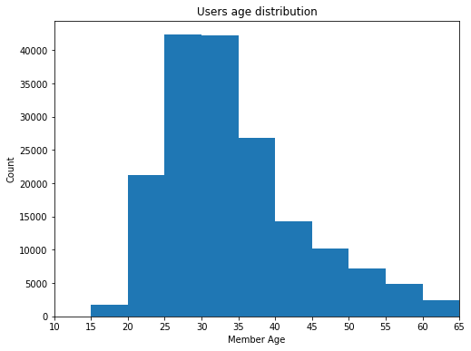

```python
# let's plot a histogram to display the riders age distribution without the outliers i.e ages below 65.

plt.figure(figsize=[8,6])

bins = np.arange(10, bike_19['member_age'].max()+5, 5)
plt.hist(data=bike_19, x='member_age', bins=bins)
plt.title('Users age distribution')
plt.xticks(bins, bins)
plt.xlabel('Member Age')
plt.xlim([10,65])
plt.ylabel('Count');
```

### Observation

> From the plot above, it is observed that in the month of February 2019,
> - The majority of the users are between the age of **25-35**.

### Visualization- The user type,gender and bike share program distribution

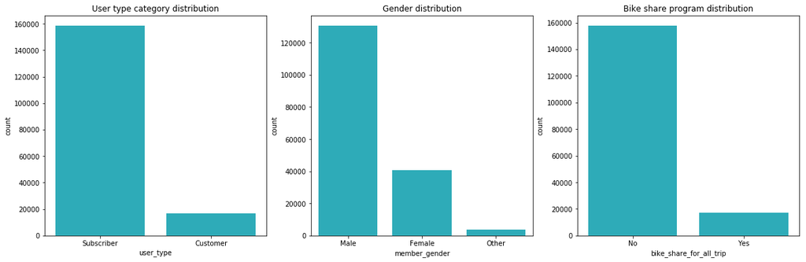

```python
# let's plot the user type, gender and bike share together to get an idea of each ordinal variable's distribution.

fig, ax = plt.subplots(ncols=3, figsize = [20,6])

plotcolor = sb.color_palette()[9]

sb.countplot(data = bike_19,x = 'user_type',color = plotcolor,order=bike_19.user_type.value_counts().index,ax = ax[0])
ax[0].set_title('User type category distribution');

sb.countplot(data = bike_19,x = 'member_gender',color = plotcolor, order=bike_19.member_gender.value_counts().index,ax = ax[1])
ax[1].set_title('Gender distribution');

sb.countplot(data = bike_19,x = 'bike_share_for_all_trip',color = plotcolor, order=bike_19.bike_share_for_all_trip.value_counts().index,ax = ax[2])
ax[2].set_title('Bike share program distribution');
```

### Observation

> From the plot above, it is observed that in the month of February 2019,
> - The number of **subscribers** were more than the **customers**
> - The **male** users rented more bikes than the others.
> - Majority of the users are not members of the bike share program.

### Question- Which start stations are most used?

### Visualization

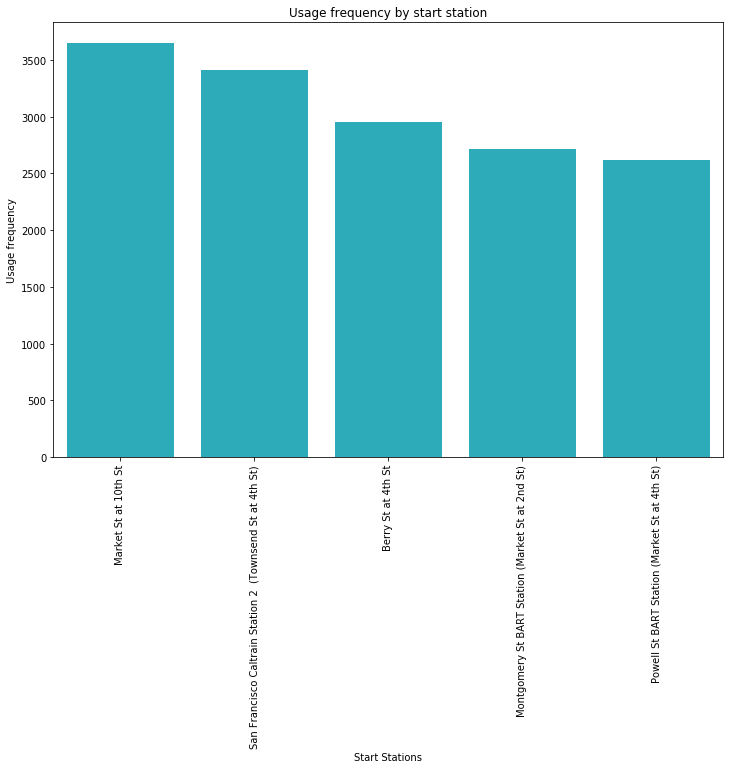

```python
plt.figure(figsize=[12, 8])


sb.countplot(data = bike_19, x = 'start_station_name', color = plotcolor,order=bike_19.start_station_name.value_counts().index[:5])
plt.title('Usage frequency by start station')
plt.xlabel('Start Stations')
plt.xticks(rotation=90)
plt.ylabel('Usage frequency');
```

### Observation

> From the plot above, it is observed that
> - The most frequently used start station is **Market St at 10th St** with users over 3500. We can use this information to increase the number of available bikes in this stations as well as the others among the top 5 stations.

### Lets deal with outliers in Age and Duration variable

```python
# Total outliers present
outliers= ((bike_19.member_age>65) | (bike_19.duration_min>100))
print(outliers.sum())
```

```
2074
```

The total number of outliers are 2074 making it very hard to investigate each one of them and deciding if they need to be filtered out of the data. However, this number is statistically insignificant (less than 5%) as compared to the total sample . Therefore,creating a dataframe without the outliers seems appropriate.

```python
#Removing the outliers from the data

bike_19=bike_19[-outliers]

bike_19.shape
```

```
(172878, 9)
```

```python
#saving the cleaned data
bike_19.to_csv('bike_19_clean.csv', index=False)
```

### Discuss the distribution(s) of your variable(s) of interest. Were there any unusual points? Did you need to perform any transformations?

> From the univariate plots above of the vairiables of interest , the following were discovered;

> User demographics:
> - User type- From the plot above it is evident that the subscribers were more than the customers
> - Member_gender- We had more male users compared to the female gender and insignificant number of trips belonging to other gender
> - Age- The predominant age group was between 25 and 35 years. The age variable was engineered from the birth year.The distribution of this plot was initially rightly skewed due to presence of outliers setting the xlim to 65 generated a clearer distribution
> - Bike_share_trip- Majority of the users are not subcribers of the bike share program

> Service usage:
> - Duration -Most trip duration was between approximately 5-25mins, this information was obtained after plotting on a log scale and setting the xlim to 100minutes.
> - Weekdays/hr- The bike rental system was found to have its peak usage on Thursdays and Tuesdays around the hours of 8-9am and 5-6pm with trip duration of about approximately 5-25mins. The most frequently used start station is **Market St at 10th St**

### Of the features you investigated, were there any unusual distributions? Did you perform any operations on the data to tidy, adjust, or change the form of the data? If so, why did you do this?

> The duration(min) and members age features has outliers which was removed to get a better view of the distribution and these features were engineered from duration(sec) and birth year respectively

## Bivariate Exploration

```python
#To start off with, I want to look at the pairwise correlations present between features in the data.

# placing numeric variables together and categorical together
numeric_vars = ['duration_min', 'member_age', 'hr_day']
categoric_vars = ['user_type', 'member_gender','dayoftheweek','bike_share_for_all_trip']
```

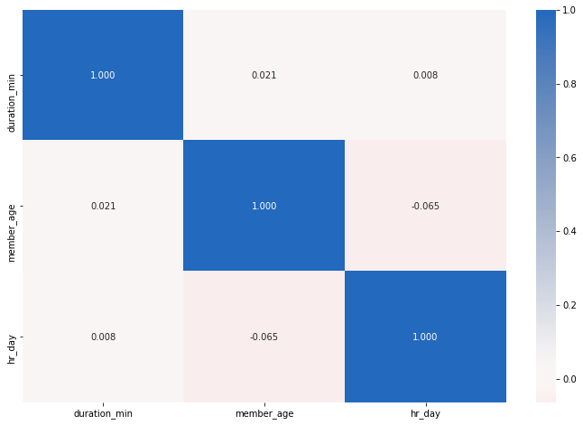

```python
# showing correlation using a heatmap plot
plt.figure(figsize = [12, 8])
sb.heatmap(bike_19[numeric_vars].corr(), annot = True, fmt = '.3f',
           cmap = 'vlag_r', center = 0);
```

### Observation

> From the plot above, it is observed that
> - The correlation cofficients indicate very weak correlation between the numeric variables.

Lets take a closer look to the correlation of age and duration using a scatter plot.

```
bike_19.shape= (172878, 9)
bike_19_samp.shape= (1000, 9)
```

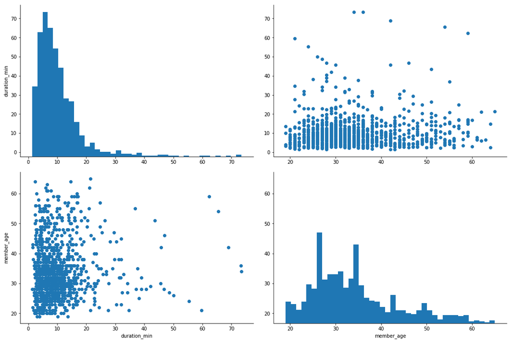

```python
# lets use a sample data of 1000 so the plot is clearer and render faster
print("bike_19.shape=",bike_19.shape)
bike_19_samp = bike_19.sample(n=1000, replace = False)
print("bike_19_samp.shape=",bike_19_samp.shape)

key_numeric_vars = ['duration_min', 'member_age']

plt.figure(figsize=[10,8])
g = sb.PairGrid(data=bike_19_samp, vars = key_numeric_vars,size=5,aspect=1.5)
g = g.map_diag(plt.hist, bins = 40)
g.map_offdiag(plt.scatter);
```

### Observation

> From the plot above, it is observed that
> - The isnt any liner relationship between the variable, although from the bottom left plot,the dense area is seen to be observed within the age of 30yrs and duration of 10mins.

### Question- Lets check out the relationship between duration,age and the various categorical variables

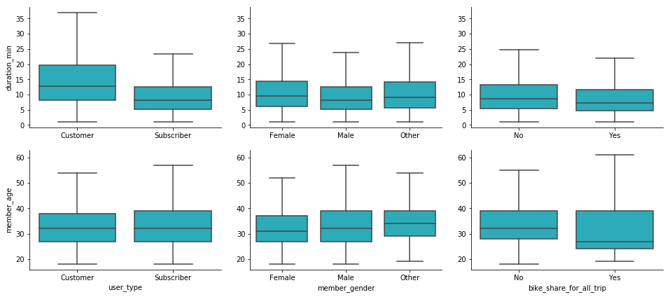

```python
# plot matrix of duration(min) and age against some categorical features('user_type', 'member_gender','bike_share_for_all_trip').

def boxgrid(x, y, **kwargs):
    """ Quick hack for creating box plots with seaborn's PairGrid. """
    default_color = sb.color_palette()[9]
    sb.boxplot(x=x, y=y, color=default_color,showfliers=False) #showfliers set to false to remove outliers

plt.figure(figsize = [20, 20]);
g = sb.PairGrid(data = bike_19, y_vars = ['duration_min','member_age'], x_vars = ['user_type', 'member_gender','bike_share_for_all_trip'],
                size = 3, aspect = 1.5);
g.map(boxgrid);
```

### Observation

> From the top plot above, it is observed that
> - Duration vs Usertype: The users who are **Customer** have longer bike trip on average as compared to users who are **Subscribers**.
> - Duration vs gender: The **Female** users have longer bike trip on average as compared to **Male** users.
> - Duration vs Bike share program: The non members on average,have longer trips compared to members of the program.

> From the bottom plot above, it is observed that
> - Age vs Usertype: The average age of the **Customer and Subscriber** users is approximately same.
> - Age vs Gender: The average age of the **Male** users is higher than the average age of the **Female** users.
> - Age vs Bike share program: The average age of non members is higher than that of the members.

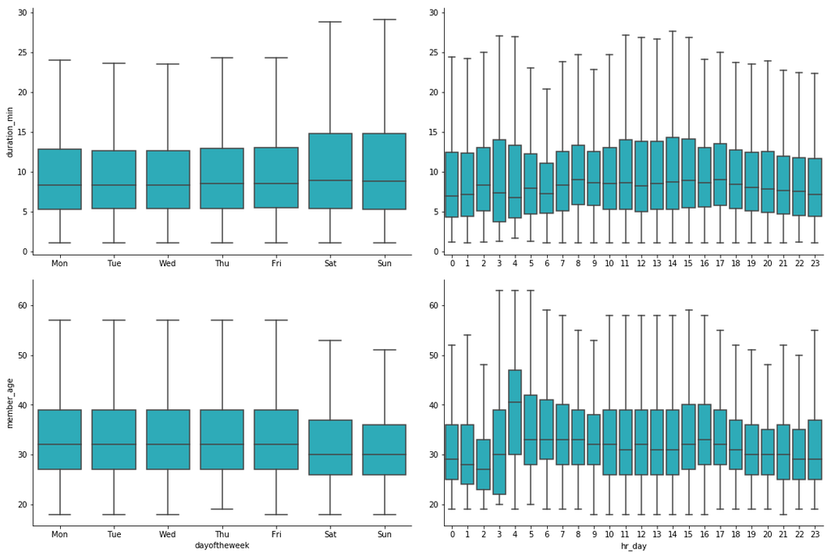

```python
# plot matrix of duration(min) and age against some categorical features('dayoftheweek','hr_day').

def boxgrid(x, y, **kwargs):
    """ Quick hack for creating box plots with seaborn's PairGrid. """
    default_color = sb.color_palette()[9]
    sb.boxplot(x=x, y=y, color=default_color,showfliers=False)

plt.figure(figsize = [20, 20]);
g = sb.PairGrid(data = bike_19, y_vars = ['duration_min','member_age'], x_vars = ['dayoftheweek','hr_day'],
                size = 5, aspect = 1.5)
g.map(boxgrid)
plt.show();
```

### Question- Lets check out the distribution of user types across various categorical variables

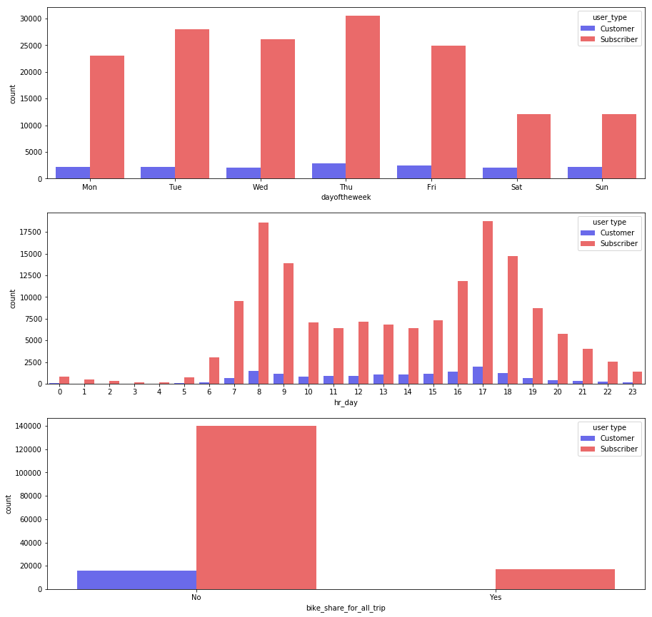

```python
plt.figure(figsize = [15, 15])

# subplot 1: user type vs day of the week
plt.subplot(3, 1, 1)
sb.countplot(data = bike_19, x = 'dayoftheweek', hue = 'user_type', palette = 'seismic')


# subplot 2: user_type vs hour of the day
ax = plt.subplot(3, 1, 2)
sb.countplot(data = bike_19, x = 'hr_day', hue = 'user_type', palette = 'seismic')
ax.legend(title='user type')

# subplot 3: user_type vs bike_share_for_all_trip,
ax = plt.subplot(3, 1, 3)
sb.countplot(data = bike_19, x = 'bike_share_for_all_trip', hue = 'user_type',palette = 'seismic')
ax.legend(title='user type')
plt.show()
```

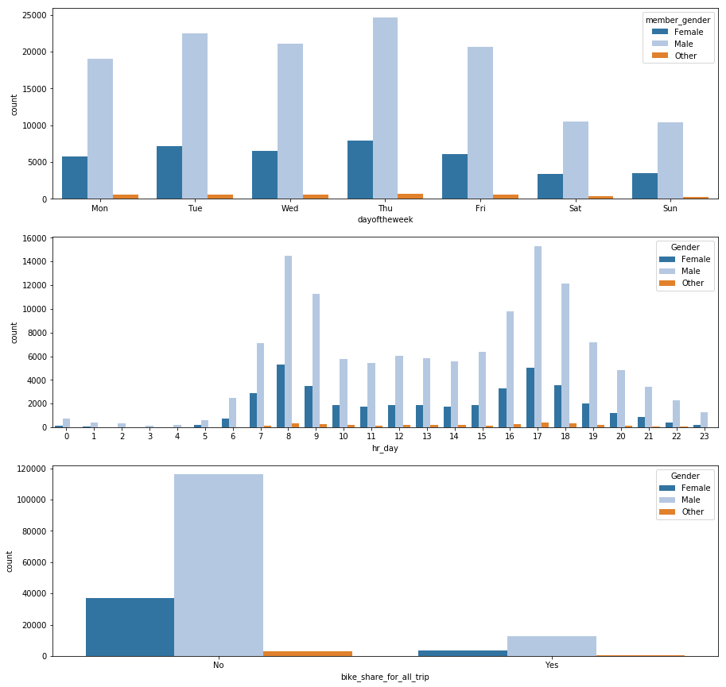

```python
plt.figure(figsize = [15, 15])

# subplot 1: gender vs day of the week
plt.subplot(3, 1, 1)
sb.countplot(data = bike_19, x = 'dayoftheweek', hue = 'member_gender', palette = 'tab20')


# subplot 2: gender vs hour of the day
ax = plt.subplot(3, 1, 2)
sb.countplot(data = bike_19, x = 'hr_day', hue = 'member_gender', palette = 'tab20')
ax.legend(title='Gender')

# subplot 3: gender vs bike_share_for_all_trip,
ax = plt.subplot(3, 1, 3)
sb.countplot(data = bike_19, x = 'bike_share_for_all_trip', hue = 'member_gender',palette = 'tab20')
ax.legend(title='Gender')
plt.show()
```

### Observation

> From the plots above, it is observed that
> - Overall, male bikers have the highest number of trips accross 7days of the week and 24hrs of the day
> - Thursday 8Am and 5PM has the highest number of trips and this also has the highest male and female compared to other days and time
> - The subcribers of the Bike share program is composed of more male compared to the other gender.

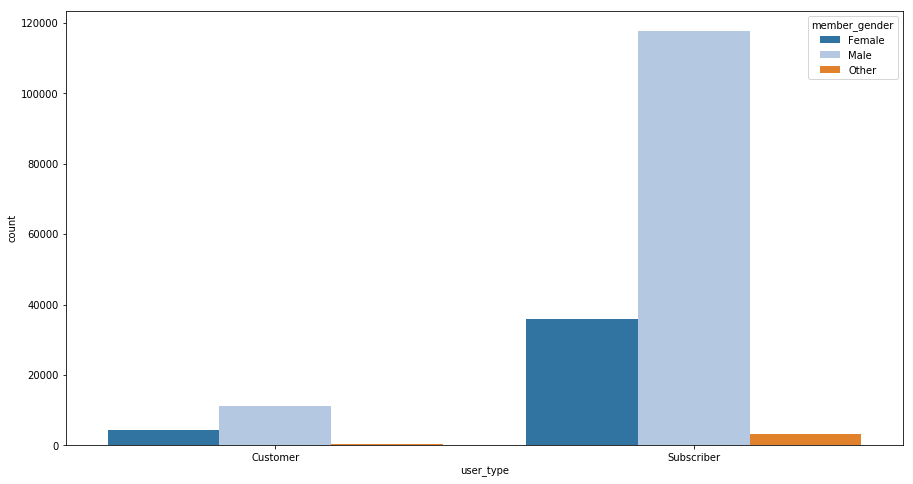

```python
plt.figure(figsize = [15, 8])

#user type vs gender
sb.countplot(data = bike_19, x = 'user_type', hue = 'member_gender', palette = 'tab20');
```

### Observation

> From the plot above, it is observed that
> - Among the user type, Subscribers are mostly male as well as the customers , but the male subscribers are considerably higher than the male customers, this applies to the female gender too.

### Talk about some of the relationships you observed in this part of the investigation. How did the feature(s) of interest vary with other features in the dataset?

> The bike share program is only available to subscribers as there is no record of any customer usage.

## Multivariate Exploration

### Question-What is the average duration across the weekdays and hours for each user type

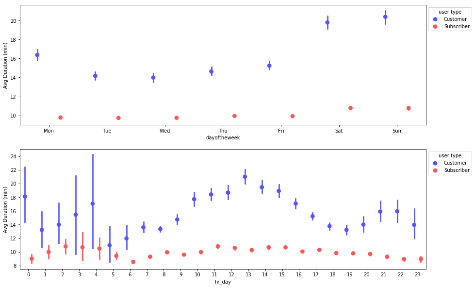

```python
plt.figure(figsize = [15, 10])

plt.subplot(2, 1, 1)
ax1=sb.pointplot(data=bike_19, x='dayoftheweek', y='duration_min', hue='user_type', palette='seismic', linestyles = '', dodge = 0.4)
ax1.set_ylabel('Avg Duration (min)')
ax1.legend(loc=2, title='user type',bbox_to_anchor=(1,1))

plt.subplot(2, 1, 2)
ax2=sb.pointplot(data=bike_19, x='hr_day', y='duration_min', hue='user_type', palette='seismic',linestyles = '', dodge = 0.4)
ax2.set_ylabel('Avg Duration (min)')
ax2.legend(loc=2,title='user type',bbox_to_anchor=(1,1))
plt.show()
```

### Observation

> From the plots above, it is observed that
> - Customers have higher average trip duration for all days of the week and hours of the day, although they spend longer times on weekends than on weekdays.

### Question-What is the average duration across the weekdays and hours for each gender

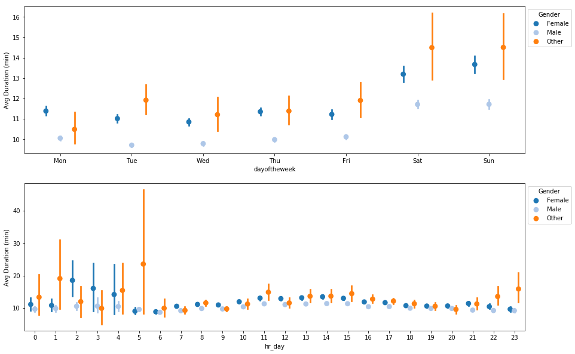

```python
plt.figure(figsize = [15, 10])

plt.subplot(2, 1, 1)
ax1=sb.pointplot(data=bike_19, x='dayoftheweek', y='duration_min', hue='member_gender', palette='tab20', linestyles = '', dodge = 0.4)
ax1.set_ylabel('Avg Duration (min)')
ax1.legend(loc=2, title='Gender',bbox_to_anchor=(1,1))

plt.subplot(2, 1, 2)
ax2=sb.pointplot(data=bike_19, x='hr_day', y='duration_min', hue='member_gender', palette='tab20',linestyles = '', dodge = 0.4)
ax2.set_ylabel('Avg Duration (min)')
ax2.legend(loc=2,title='Gender',bbox_to_anchor=(1,1))
plt.show()
```

### Observation

> From the plots above, excluding the unidentified gender(other) it is observed that
> - Female users have higher average trip duration for all days of the week and almost all hours of the day except for 5am where the male users spend longer time,
> - The female users also spend longer times on weekends than on weekdays.

### Question-What is the relationship between age,duration,user type,gender and weekdays.

```python
def log_trans(x, inverse=False):
    if not inverse:
        return np.log10(x)
    else:
        return np.power(10, x)
bike_19['log_duration'] = bike_19['duration_min'].apply(log_trans)
```

```python
bike_19.log_duration.describe()
```

```
count    172878.000000
mean          0.924019
std           0.291228
min           0.007179
25%           0.729705
50%           0.928567
75%           1.115611
max           1.998985
Name: log_duration, dtype: float64
```

```python
bike_19.member_age.describe()
```

```
count    172878.000000
mean         33.877711
std           9.458570
min          18.000000
25%          27.000000
50%          32.000000
75%          39.000000
max          65.000000
Name: member_age, dtype: float64
```

```python
def hist2dgrid(x, y, **kwargs):
    """ Quick hack for creating heat maps with seaborn's PairGrid. """
    palette = kwargs.pop('color');
    bins_x = np.arange(18, bike_19['member_age'].max()+2, 2);
    bins_y = np.arange(0, 2, 0.1);
    plt.hist2d(x, y, bins = [bins_x, bins_y], cmap = palette, cmin = 0.5);
    plt.yticks(log_trans(np.array([1, 2, 5, 10, 20, 50, 100])),
               [1, 2, 5, 10, 20, 50, 100]);
```

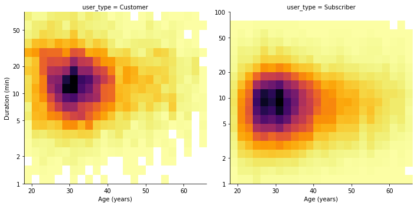

```python
g = sb.FacetGrid(data = bike_19, col = 'user_type', size=5)
g.map(hist2dgrid, 'member_age', 'log_duration', color='inferno_r')
g.set_xlabels('Age (years)')
g.set_ylabels('Duration (min)')
plt.show();
```

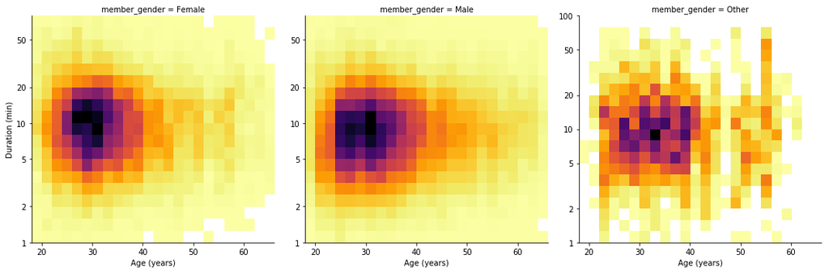

```python
g = sb.FacetGrid(data = bike_19, col = 'member_gender', size=5)
g.map(hist2dgrid, 'member_age', 'log_duration', color='inferno_r')
g.set_xlabels('Age (years)')
g.set_ylabels('Duration (min)')
plt.show();
```

### Question-What is the characteristics of the users of the Top 3 start stations

```python
Top3station=bike_19.start_station_name.value_counts().index[:3]
Top3station
```

```
Index(['Market St at 10th St',
       'San Francisco Caltrain Station 2  (Townsend St at 4th St)',
       'Berry St at 4th St'],
      dtype='object')
```

```python
bike_19sub=bike_19.loc[bike_19['start_station_name'].isin (Top3station)]
```

```python
bike_19sub.start_station_name.value_counts().index[:3]
```

```
Index(['Market St at 10th St',
       'San Francisco Caltrain Station 2  (Townsend St at 4th St)',
       'Berry St at 4th St'],
      dtype='object')
```

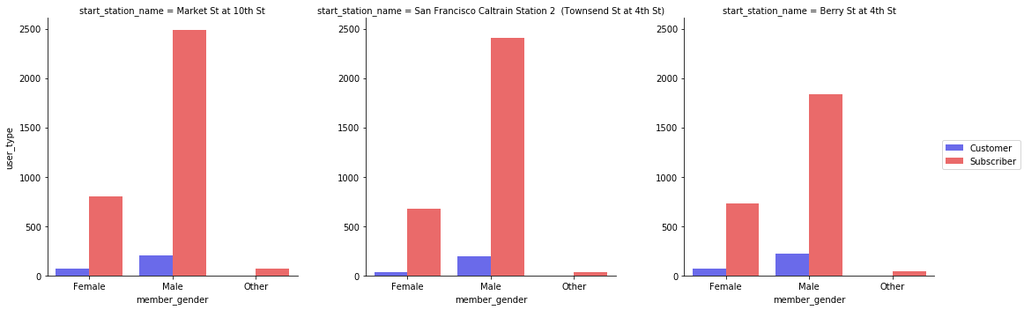

```python
def countplot(x,hue, **kwargs):
    sb.countplot(x=x,hue=hue, **kwargs)
g=sb.FacetGrid(data=bike_19sub,col='start_station_name',size=5,aspect=1)
g.map(countplot,'member_gender','user_type',palette='seismic',order=bike_19sub.member_gender.unique())
g.add_legend();
```

### Observation

> From the plots above, focusing on male and female gender,it is observed that
> - The male subscribers are majority in numbers in all the 3 stations compare to the female subscribers
> - The female subscriber for **Market st at 10th st** is higher than that of other stations

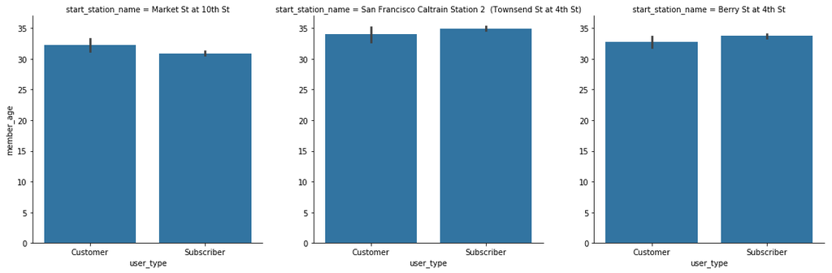

```python
g=sb.FacetGrid(data=bike_19sub,col='start_station_name',size=5)
g.map(sb.barplot,'user_type','member_age');
```

### Observation

> From the plots above,it is observed that
> - The mean age of the subscribers is greater than that of the customers except for **Market st at 10th st** where the mean age of the customers is higher.

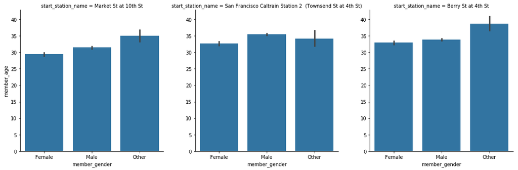

```python
g=sb.FacetGrid(data=bike_19sub,col='start_station_name',size=5)
g.map(sb.barplot,'member_gender','member_age');
```

### Observation

> From the plots above, focusing on male and female gender,it is observed that
> - The male users are older in all 3 stations compared to the female gender

### Talk about some of the relationships you observed in this part of the investigation. Were there features that strengthened each other in terms of looking at your feature(s) of interest?

> The multivariate exploration/visualization strengthened some of the patterns discovered in the previous bivariate exploration as well as univariate exploration, the relationship between multiple categorical variables and numerical variables are visualized altogether and observations were noted.

### Were there any interesting or surprising interactions between features?

> There wasnt any strong relationship between age and duration, one will assume that the older you get , the lesser the duration of the ride

## Conclusions

> From the exploration of bike rides in Feb 2019, The following were observed in summary;
> - **Usage summary**:-
> - The duration of each trip was approximately between 5-25mins.
> - Most trips were observed for Thursdays and Tuesdays with peak times of 8Am and 5pm.This can be attributed to members using the bikes to commute to work and back home.
> - Also lesser trips were observed during the weekend strengthning the intuition that the user base is comprised mostly of those commuting to work.
> - The most used start station is Market St at 10th St.
> - Customers and female users have longer trip durations
> - In general trip durations in weekend is higher than weekdays
> - The top 3 start stations were dominated by male subscribers who on average are older than the female subcribers. *
> - **Users Summary**-
> - The subscribers are more than the customers.
> - The Male gender is predominant amongst the users.
> - The predominant age is between 25-35 years
> - Only few subscribers are part of the bike_share program